# Trouver la racine d’une fonction

Paul Moulaire

30/10/2021

### 1. Trouver la racine d’une fonction affine

#### 1.1 Générer une fonction affine aléatoire

```r
a<-sample(c(-10:10),1)
b<-sample(c(1:10),1)

a
```

```
## [1] -4
```

```r
b
```

```
## [1] 10
```

```r
f<-function(x) (a+b*(x))
```

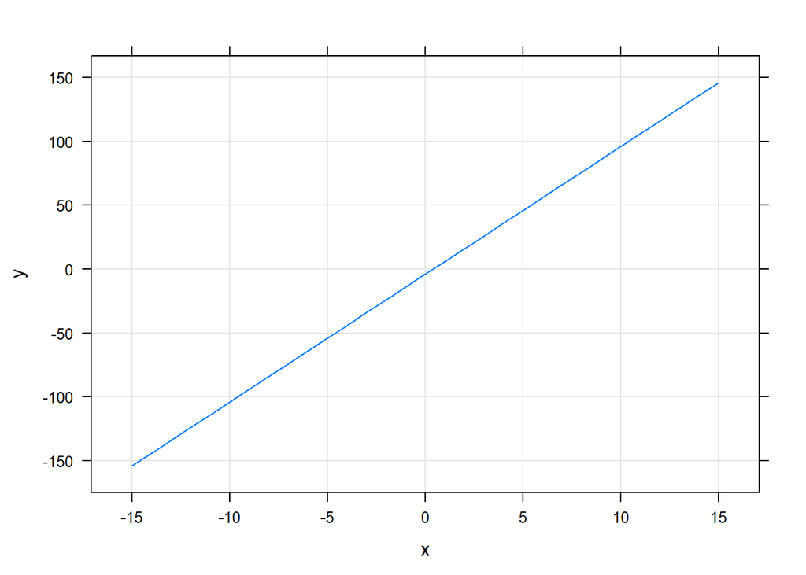

#### 1.2 Définir un point de départ et un delta souhaité pour calculer le coéfficient directeur de la droite:

```r
c<-1
delta<-1
```

#### 1.3 Calcul du coéficient directeur de la droite pour une unité de x et calcul de l’ordonnée à l’origine

```r
coef_d<-(f(c+delta)-f(c))*1/delta
coef_d
```

```
## [1] 10
```

```r
B0<-f(c)-c*coef_d
B0
```

```
## [1] -4
```

#### 1.4 Calcul de la racine de la fonction avec le coéfficient directeur et l’ordonnée à l’origine

```r
x0<- -B0/coef_d
x0
```

```
## [1] 0.4
```

```r
f(x0)
```

```
## [1] 0
```

### 2. Trouver la racine d’une fonction non affine

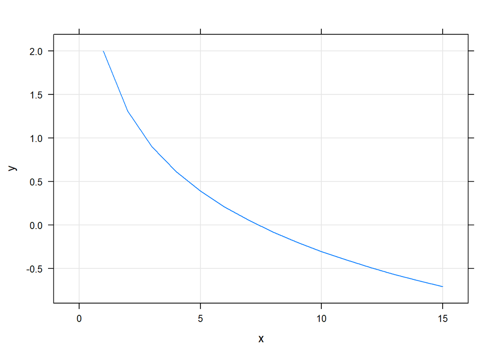

```r
f<-function(x) (-log(x)+2)
```

#### 2.1 Définir un point de départ(x0),une précision souhaitée (p) et un nombre maximal (n) d’ittérations de la boucle.

```r
x0<-0.5
p<-0
n<-100
```

#### 2.1 Création d’une boucle, qui va chercher la racine de la fonction.

sur le même principe que pour une fonction affine, la boucle va chercher une valeur x0 telle que f(x0)=0, puis va comparer ce résultat à 0 +/- la précision souhaitée. Si la condition n’est pas validée, on recommence, un maximum de n fois, en prenant le dernier x0 trouvé comme nouvelle valeur de départ.

nb: Si on veut un résultat “exact” on fixe p à 0.

```r
for(i in 1:n){
  c[i]<-x0
  x0<- -(f(c[i])-c[i]*((f(c[i]+0.01)-f(c[i]))*1/0.01))/((f(c[i]+0.01)-f(c[i]))*1/0.01)
  if(f(x0)>=-p & f(x0)<=p) break
}
x0
```

```
## [1] 7.389056
```

```r
f(x0)
```

```
## [1] 0
```

### Remarques:

Ce code trouve uniquement UNE solution x0 telle que f(x0)=0 +/- p.

Si l’on suspecte l’existance de plusieurs valeurs de x, telles que f(x)=0, on peut faire varier le point de départ (x0) de la boucle à la recherche d’autres solutions.

Il existe à priori un fonction intégrée dans R (?uniroot) ainsi qu’un package dédié à la recherche de racines de fonctions “rootSolve” qui s’applique dans de plus larges cas:

https://cran.r-project.org/web/packages/rootSolve/vignettes/rootSolve.pdf